# M2_891_20251_PEC3_Jsolanm

## 3.4. Modelización (1.5 puntos)

La modelización es una fase crucial en la que tenemos que tomar muchas decisiones y ser muy rigurosos con la metodología. Varios de los puntos clave en esta fase son los siguientes:

- **Selección y configuración del modelo**: Elegir el algoritmo de clasificación más adecuado según el problema, los datos y los objetivos (por ejemplo, SVM, árboles de decisión, etc.), definiendo también los criterios de evaluación.
- **Entrenamiento y ajuste de hiperparámetros**: Entrenar el modelo con los datos disponibles y realizar una búsqueda de hiperparámetros (grid search, random search o técnicas bayesianas).
- **Evaluación y validación del modelo**: Medir el desempeño del modelo con métricas adecuadas (precisión, recall, F1-score, AUC, etc.) y validar su comportamiento con técnicas como la validación cruzada.
- **Explicabilidad del modelo**: Analizar e interpretar cómo y por qué el modelo toma decisiones, utilizando herramientas como coeficientes, SHAP, LIME o visualización de soporte vectorial, para asegurar transparencia y confianza en el uso del modelo.

**Implementación:** Este ejercicio lo vamos a abordar utilizar un modelo árbol de decisión. Para ello:

1. Define un clasificador `DecisionTreeClassifier` de la biblioteca `tree` de `sklearn` sin especificar ningún parámetro y calcula su precisión sobre el conjunto de train aplicando validación cruzada con 5 conjuntos.
2. Entrena un nuevo modelo sobre el conjunto de datos de train.
3. Calcula las siguientes métricas tanto en los datos de *train* como de *test*:
   - Calcula la exactitud (accuracy) para medir la exactitud de las predicciones.
   - Calcula el valor F1, que es una medida que combina exactitud y sensibilidad.
4. Calcula la matriz de confusión utilizando los datos de *test*.

Utiliza el módulo `cross_val_score` de `sklearn` para aplicar la validación cruzada con el clasificador DecisionTree (de `DecisionTreeClassifier` de `sklearn`).

```
VALIDACIÓN CRUZADA - DECISION TREE
Scores de cada fold: [0.65268226 0.64649243 0.68500688 0.66276669 0.65932553]
Precisión media: 0.6613

MÉTRICAS DE RENDIMIENTO
==================================================
Métrica              Train           Test
==================================================
Accuracy             0.9994          0.6703
F1-Score             0.9994          0.5993
==================================================

MATRIZ DE CONFUSIÓN (TEST)
[[770 256]
 [343 448]]
```

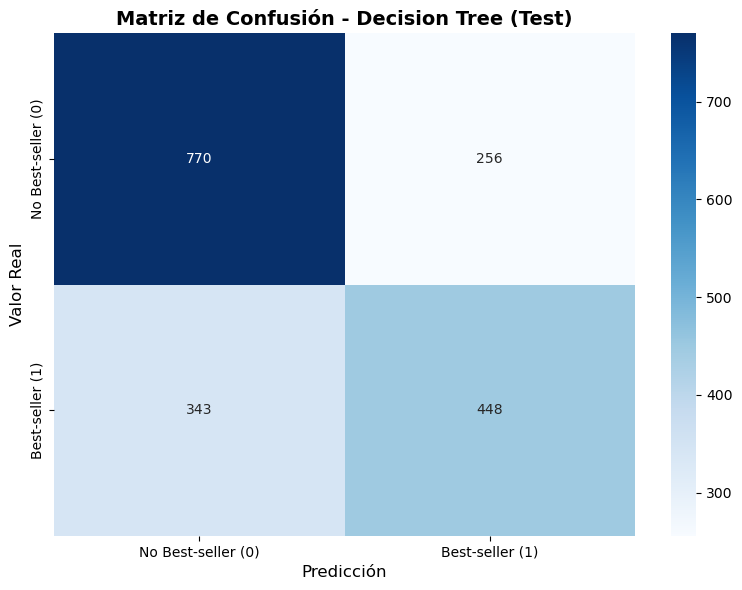

```python
# 1. Árbol de decisión

# Creamos el clasificador sin parámetros
dt_classifier = DecisionTreeClassifier(random_state=seed)

cv_scores = cross_val_score(dt_classifier, X_train_scaled, y_train, cv=5, scoring='accuracy')

print("VALIDACIÓN CRUZADA - DECISION TREE")
print(f"Scores de cada fold: {cv_scores}")
print(f"Precisión media: {cv_scores.mean():.4f}")

# 2. Entrenamos con train
dt_classifier.fit(X_train_scaled, y_train)


# 3. Métricas en train y test

# Predicciones
y_train_pred = dt_classifier.predict(X_train_scaled)
y_test_pred = dt_classifier.predict(X_test_scaled)

# Calcular métricas
train_accuracy = accuracy_score(y_train, y_train_pred)
test_accuracy = accuracy_score(y_test, y_test_pred)

train_f1 = f1_score(y_train, y_train_pred)
test_f1 = f1_score(y_test, y_test_pred)

print("\nMÉTRICAS DE RENDIMIENTO")
print("="*50)
print(f"{'Métrica':<20} {'Train':<15} {'Test':<15}")
print("="*50)
print(f"{'Accuracy':<20} {train_accuracy:<15.4f} {test_accuracy:<15.4f}")
print(f"{'F1-Score':<20} {train_f1:<15.4f} {test_f1:<15.4f}")
print("="*50)


# 4. Matriz de confusión
cm = confusion_matrix(y_test, y_test_pred)

print(f"\nMATRIZ DE CONFUSIÓN (TEST)")
print(cm)

# Visualizar la matriz de confusión
plt.figure(figsize=(8, 6))
sns.heatmap(cm, annot=True, fmt='d', cmap='Blues', cbar=True,
            xticklabels=['No Best-seller (0)', 'Best-seller (1)'],
            yticklabels=['No Best-seller (0)', 'Best-seller (1)'])
plt.title('Matriz de Confusión - Decision Tree (Test)', fontsize=14, fontweight='bold')
plt.ylabel('Valor Real', fontsize=12)
plt.xlabel('Predicción', fontsize=12)
plt.tight_layout()
plt.show()
```

**Análisis:**

1. Realiza un análisis de los resultados y decide si consideras que este modelo es aceptable.
2. Evalúa cuál de las medidas de rendimiento utilizadas es la más apropiada.
3. Examina la distribución de las clases y plantea una estrategia, si es necesario, para asegurar la confiabilidad del estudio realizado.

**Respuesta:**

### 1

El modelo tal cual no es aceptable, nos ha pasado algo parecido a la primera vez que hemos realizado un modelo con árbol de decisión en el ejercicio anterior, tenemos overfitting.

Viendo la accuracy obtenida en train `0.9994` y comparada con la obtenida en los datos de test `0.6703` nos damos cuenta de este fallo.

### 2

En cuanto a la medida de rendimiento más adecuada, la accuracy no sería la más apropiada debido a la diferencia de clasesde los datos, más juegos normales que Best-sellers. Una accuracy del 67% podría parecer decente, pero si miramos la matriz de confusión, vemos errores significativos.

La métrica más adecuada sería el F1-score , ya que combina la Precisión y la Recall. Dado que el objetivo es detectar "Best-sellers", nos interesa un equilibrio, no queremos perdernos éxitos potenciales (falsos negativos), pero tampoco queremos etiquetar todo como éxito.

### 3

Para corregir este sobreajuste que hemos visto lo mejor sería realizar una poda del árbol como en el apartado anterior, modificando dos hiperparámetros como:

- max_depth. Limita la profundida máxima del árbol
- min_samples_split. Indica el ínimo de muestras para dividir un nodo

**Implementación:** Repite el procedimiento anterior considerando la estrategia que consideres necesaria para mejorar la confiabilidad del modelo.

[output not shown]

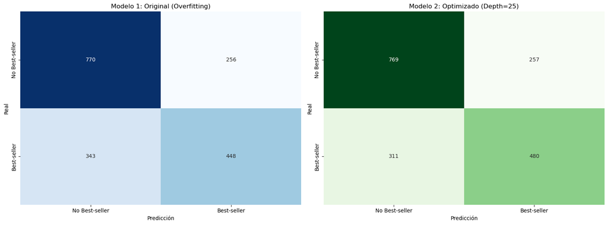

```python
# Como en el 1.6, hacemos un pequeño banco de pruebas para ver la mejor combinación

# Definimos el modelo base (con balanceo de clases)
dt_base = DecisionTreeClassifier(random_state=seed, class_weight='balanced')

# Definimos la rejilla de parámetros a probar
param_grid = {
    'max_depth': [10, 15, 20, 25, 30],        # Profundidad del árbol
    'min_samples_split': [5, 10, 20],        # Mínimo para dividir nodo
}

# Configuramos el GridSearch
# scoring='f1': Importante, le pedimos que maximice F1, no Accuracy, por el desbalanceo
grid_search = GridSearchCV(
    estimator=dt_base,
    param_grid=param_grid,
    cv=5,
    scoring='f1',
    n_jobs=-1
)

grid_search.fit(X_train_scaled, y_train)

# Obtenemos el mejor modelo y sus parámetros
dt_classifier_balanced = grid_search.best_estimator_
print(f"\nMEJORES HIPERPARÁMETROS ENCONTRADOS:")
print(grid_search.best_params_)
print(f"Mejor F1-Score en validación interna: {grid_search.best_score_:.4f}")

# cross validation
cv_scores_balanced = cross_val_score(
    dt_classifier_balanced,
    X_train_scaled,
    y_train,
    cv=5,
    scoring='accuracy' # Aquí medimos accuracy para comparar, aunque optimizamos F1
)

print(f"\nVALIDACIÓN CRUZADA - MEJOR ÁRBOL BALANCEADO")
print(f"Scores de cada fold: {cv_scores_balanced}")
print(f"Precisión media: {cv_scores_balanced.mean():.4f}")
print(f"Desviación estándar: {cv_scores_balanced.std():.4f}")


dt_classifier_balanced.fit(X_train_scaled, y_train)

# Predicciones
y_train_pred_balanced = dt_classifier_balanced.predict(X_train_scaled)
y_test_pred_balanced = dt_classifier_balanced.predict(X_test_scaled)

# Calcular métricas
train_accuracy_balanced = accuracy_score(y_train, y_train_pred_balanced)
test_accuracy_balanced = accuracy_score(y_test, y_test_pred_balanced)

train_f1_balanced = f1_score(y_train, y_train_pred_balanced)
test_f1_balanced = f1_score(y_test, y_test_pred_balanced)

print("\nMÉTRICAS DE RENDIMIENTO - MODELO FINAL")
print("="*50)
print(f"{'Métrica':<20} {'Train':<15} {'Test':<15}")
print("="*50)
print(f"{'Accuracy':<20} {train_accuracy_balanced:<15.4f} {test_accuracy_balanced:<15.4f}")
print(f"{'F1-Score':<20} {train_f1_balanced:<15.4f} {test_f1_balanced:<15.4f}")
print("="*50)

# Matriz de confusión
cm_balanced = confusion_matrix(y_test, y_test_pred_balanced)

print(f"\nMATRIZ DE CONFUSIÓN (TEST) - MODELO FINAL")
print(cm_balanced)

# Visualizar comparación
fig, axes = plt.subplots(1, 2, figsize=(16, 6))

# Matriz original
sns.heatmap(cm, annot=True, fmt='d', cmap='Blues', cbar=False, ax=axes[0],
            xticklabels=['No Best-seller', 'Best-seller'],
            yticklabels=['No Best-seller', 'Best-seller'])
axes[0].set_title('Modelo 1: Original (Overfitting)', fontsize=12)
axes[0].set_ylabel('Real')
axes[0].set_xlabel('Predicción')

# Matriz balanceada
sns.heatmap(cm_balanced, annot=True, fmt='d', cmap='Greens', cbar=False, ax=axes[1],
            xticklabels=['No Best-seller', 'Best-seller'],
            yticklabels=['No Best-seller', 'Best-seller'])
axes[1].set_title(f'Modelo 2: Optimizado (Depth={grid_search.best_params_["max_depth"]})', fontsize=12)
axes[1].set_ylabel('Real')
axes[1].set_xlabel('Predicción')

plt.tight_layout()
plt.show()
```

**Análisis:** Justifica la respuesta para cada una de las siguientes preguntas:

1. ¿Has conseguido mejorar el rendimiento del modelo? ¿es suficiente?
2. ¿Hay algún atributo descriptivo que no lo consideres válido para el problema que estamos resolviendo?
3. ¿Cómo consideras que podríamos mejorar el rendimiento del modelo?

**Respuesta:**

**Implementación:** Los árboles de decisión nos permiten calcular la contribución relativa de cada atributo descriptivo al rendimiento predictivo del modelo. Para ello,

1. Calcula la contribución relativa de cada atributo utilizando el atributo `feature_importances_`.
2. Crea un DataFrame que contenga dos columnas, el nombre del atributo descriptivo y su contribución.
3. Ordena las filas por el valor de contribución.
4. Muestra el DataFrame resultante.

```
TOP 20 CARACTERÍSTICAS MÁS IMPORTANTES:
                                Feature  Importance
0                    User Ratings Count    0.515408
1                                  year    0.300749
2             Publisher_Electronic Arts    0.036517
3                  Publisher_Activision    0.021913
4     Product Rating_Rated M For Mature    0.019194
5                     Publisher_Ubisoft    0.016286
6                            Genres_FPS    0.011774
7   Product Rating_Rated E For Everyone    0.010967
8       Product Rating_Rated T For Teen    0.008914
9                  Genres_2D Platformer    0.008136
10                       Publisher_Sega    0.007668
11                   Publisher_2K Games    0.005811
12                   Genres_Compilation    0.005475
13                Developer_Omega Force    0.005144
14                   Publisher_Nintendo    0.004991
15     Publisher_Microsoft Game Studios    0.003802
16            Genres_Real-Time Strategy    0.003275
17              Genres_Action Adventure    0.003258
18                Publisher_NIS America    0.003027
19                     Publisher_Capcom    0.002661
```

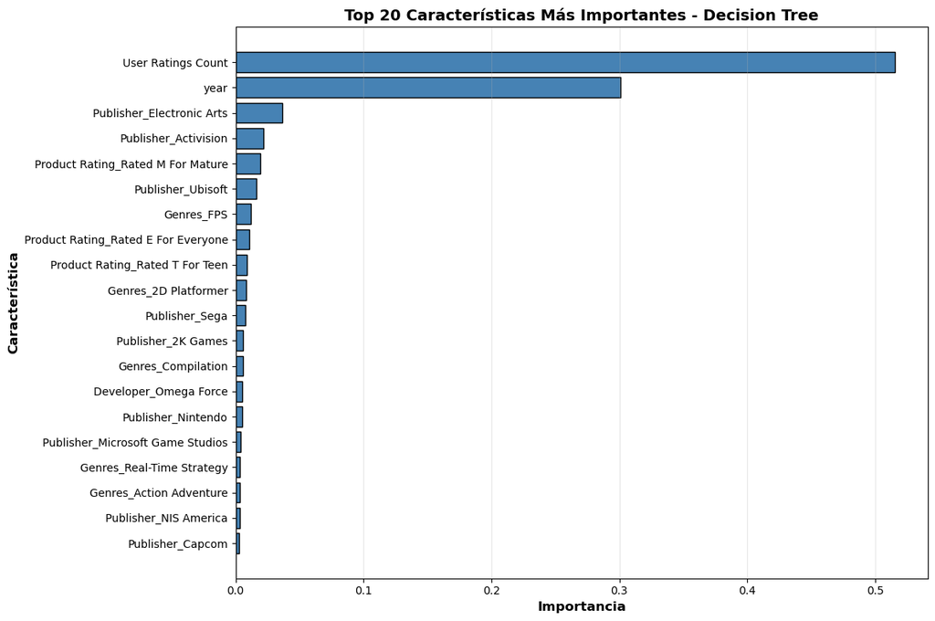

```python
# 1. Contribución relativa
# Obtenemos las importancias de las características del modelo balanceado
feature_importances = dt_classifier_balanced.feature_importances_

# 2. Creamos DataFrame con nombres de características e importancias
importance_df = pd.DataFrame({
    'Feature': X_train.columns,
    'Importance': feature_importances
})

# 3. Ordenamos por importancia (descendente)
importance_df = importance_df.sort_values('Importance', ascending=False)

# Reseteamos índice para una mejor visualización
importance_df = importance_df.reset_index(drop=True)

# 4. Visualizacion del dataset
print(f"\nTOP 20 CARACTERÍSTICAS MÁS IMPORTANTES:")
print(importance_df.head(20).to_string(index=True))


# Visualización con gráfica.
# Visualizar top 20 características más importantes
plt.figure(figsize=(12, 8))
top_20 = importance_df.head(20)
plt.barh(range(len(top_20)), top_20['Importance'], color='steelblue', edgecolor='black')
plt.yticks(range(len(top_20)), top_20['Feature'])
plt.xlabel('Importancia', fontsize=12, fontweight='bold')
plt.ylabel('Característica', fontsize=12, fontweight='bold')
plt.title('Top 20 Características Más Importantes - Decision Tree', fontsize=14, fontweight='bold')
plt.gca().invert_yaxis()  # Invertir para que la más importante esté arriba
plt.grid(axis='x', alpha=0.3)
plt.tight_layout()
plt.show()
```

**Análisis:**

Relaciona la interpretación de la contribución de los atributos descriptivos con el análisis exploratorio de los datos realizado en el ejercicio 3.2.

Al final, tal y como acabamos de ver, lo que más importa son las valoraciones de los usuarios y el año.

La lógica nos dice obviamente que para que un videojuego se venda bien tiene que gustar a la gente y por ello ser un best-seller y es verdad que depende del año puede haber más espectativas o menos por lo videojuegos, según las gráficas del 3.2, en los principios de los 2000s la mayoría de juego fueron best-seller, el auge de las consolas y los buenos juegos ayudaban pero después, cuando las empresas solo querían vender, producir más, por eso vemos también aumento en el número de juegos, el número de best-sellers cae, la calidad de los videojuegos baja y hay muchos menos en proporción con otros años.

**Respuesta:**